# MOOC_OpenDataScience

Hari Adhikari

11 November 2018

# Exercise 3

## Data Wrangling

See https://github.com/adhihari/IODS-project/blob/master/data/create_alc.R

We run libraries of “dplyr” and “ggplot2” install.packages(“ggplot2”)

Now we are reading the joined data set used in the analysis exercise combines the two student alcohol consumption data sets.

### Some background about the data

The following adjustments have been made:

The variables not used for joining the two data have been combined by averaging (including the grade variables) ‘alc_use’ is the average of ‘Dalc’ and ‘Walc’ ‘high_use’ is TRUE if ‘alc_use’ is higher than 2 and FALSE otherwise.

Although we have saved the alc.txt file in the data wrangling exercise, we are going to use alc.txt from the website Here we will print the names of the columns in the dataframe and also see the structure of the data

## Data Analysis

#### Now reading data from web

```r
alc  <- read.table("http://s3.amazonaws.com/assets.datacamp.com/production/course_2218/datasets/alc.txt", sep=",", header =T)
#names of colums present in the data
print(names(alc))
```

```
##  [1] "school"     "sex"        "age"        "address"    "famsize"
##  [6] "Pstatus"    "Medu"       "Fedu"       "Mjob"       "Fjob"
## [11] "reason"     "nursery"    "internet"   "guardian"   "traveltime"
## [16] "studytime"  "failures"   "schoolsup"  "famsup"     "paid"
## [21] "activities" "higher"     "romantic"   "famrel"     "freetime"
## [26] "goout"      "Dalc"       "Walc"       "health"     "absences"
## [31] "G1"         "G2"         "G3"         "alc_use"    "high_use"
```

```r
print(str(alc))
```

```
## 'data.frame':    382 obs. of  35 variables:
##  $ school    : Factor w/ 2 levels "GP","MS": 1 1 1 1 1 1 1 1 1 1 ...
##  $ sex       : Factor w/ 2 levels "F","M": 1 1 1 1 1 2 2 1 2 2 ...
##  $ age       : int  18 17 15 15 16 16 16 17 15 15 ...
##  $ address   : Factor w/ 2 levels "R","U": 2 2 2 2 2 2 2 2 2 2 ...
##  $ famsize   : Factor w/ 2 levels "GT3","LE3": 1 1 2 1 1 2 2 1 2 1 ...
##  $ Pstatus   : Factor w/ 2 levels "A","T": 1 2 2 2 2 2 2 1 1 2 ...
##  $ Medu      : int  4 1 1 4 3 4 2 4 3 3 ...
##  $ Fedu      : int  4 1 1 2 3 3 2 4 2 4 ...
##  $ Mjob      : Factor w/ 5 levels "at_home","health",..: 1 1 1 2 3 4 3 3 4 3 ...
##  $ Fjob      : Factor w/ 5 levels "at_home","health",..: 5 3 3 4 3 3 3 5 3 3 ...
##  $ reason    : Factor w/ 4 levels "course","home",..: 1 1 3 2 2 4 2 2 2 2 ...
##  $ nursery   : Factor w/ 2 levels "no","yes": 2 1 2 2 2 2 2 2 2 2 ...
##  $ internet  : Factor w/ 2 levels "no","yes": 1 2 2 2 1 2 2 1 2 2 ...
##  $ guardian  : Factor w/ 3 levels "father","mother",..: 2 1 2 2 1 2 2 2 2 2 ...
```

[output cut: 22 more lines]

```r
print(dim(alc))
```

```
## [1] 382  35
```

Now we see that the data frame has 382 rows and 35 columns.

We also see that we have factor, numeric, integers, and logical data types in the data frame.

###### I think that student consume more alcohol when there is lack of parential guidence,i assume that more educated father can guide his child for better future and discourage him/her for alchol consumption.

###### Next, i assume that if a student is romantic, for example if he has tragedy in life, he/she might consume more alcohol.

###### Next, Absent in class might indirectly means he is going to bar and has hangover

###### Next, failures in previous years might lead him/her to drink alchol.

#### Data types

So, i am going to see the relationships between low/high alcohol consumption and 4 different predictor variables, First i want to plot the relationships and make some analysis.

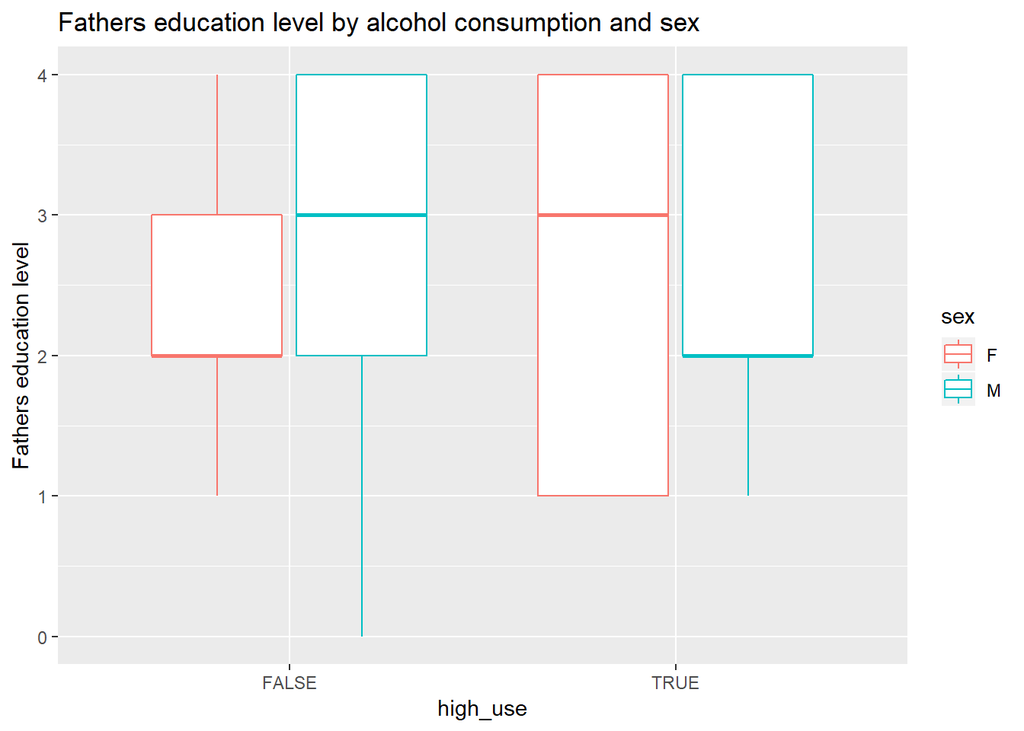

```r
# Plot high_use of alchol (true or false) based on fathers education and also see if the results differ if student is boy or girl
Feduplot <- ggplot(alc, aes(x = high_use, y = Fedu, col = sex))

# define the plot as a boxplot and draw it
Feduplot + geom_boxplot() + ylab("Fathers education level") +ggtitle("Fathers education level by alcohol consumption and sex")
```

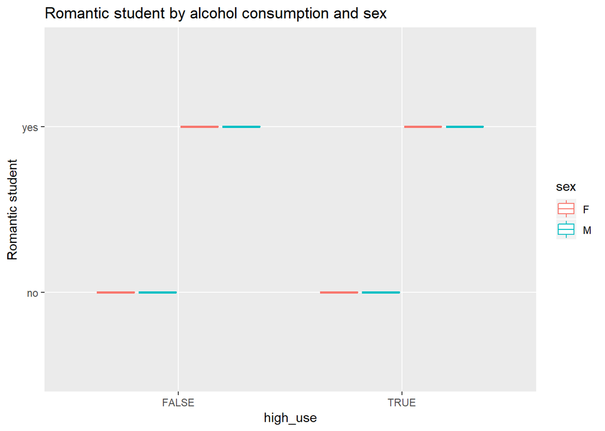

```r
# Plot high_use of alchol (true or false) based on student being romantic or not and if the results differ if student is boy or girl
Romplot <- ggplot(alc, aes(x = high_use, y = romantic, col = sex))

# define the plot as a boxplot and draw it
Romplot + geom_boxplot() + ylab("Romantic student") +ggtitle("Romantic student by alcohol consumption and sex")
```

There is no clear explanation based on student being romantic or not.

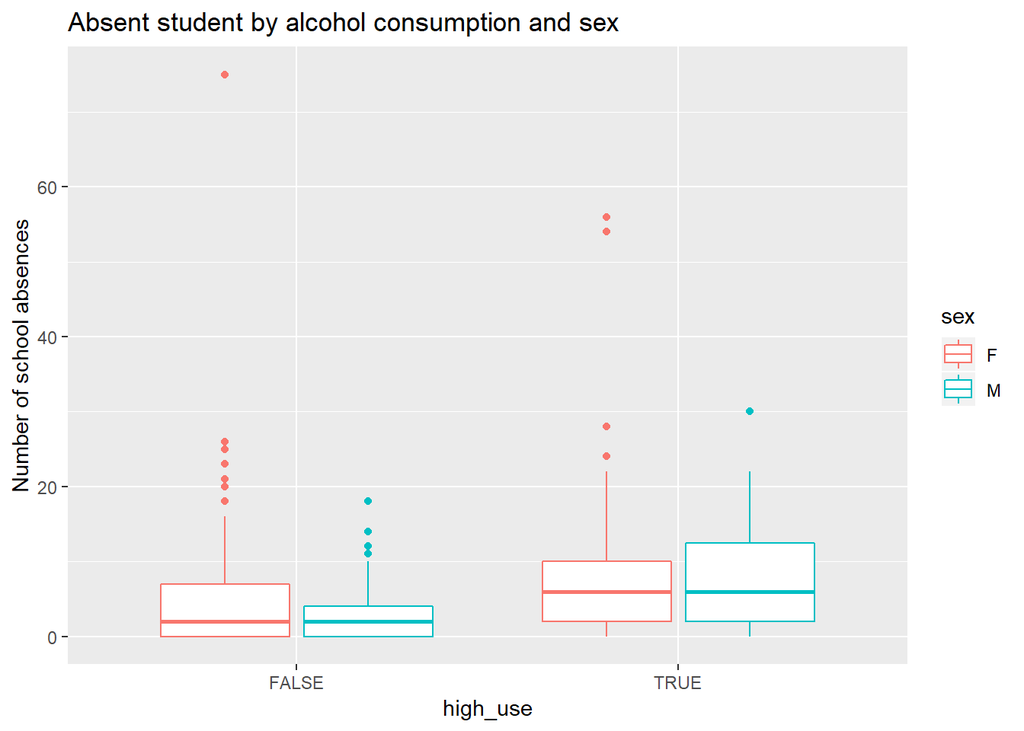

```r
# Plot high_use of alchol (true or false) based on student being absent for many days in the school and if the results differ if student is boy or girl
Romplot <- ggplot(alc, aes(x = high_use, y = absences, col = sex))

# define the plot as a boxplot and draw it
Romplot + geom_boxplot() + ylab("Number of school absences") +ggtitle("Absent student by alcohol consumption and sex")
```

This shows that student who is absent for many days specially boys and girls are more prone to high alchol consumption.Also, girls tends to be more absent than boys in the class.

names(alc)

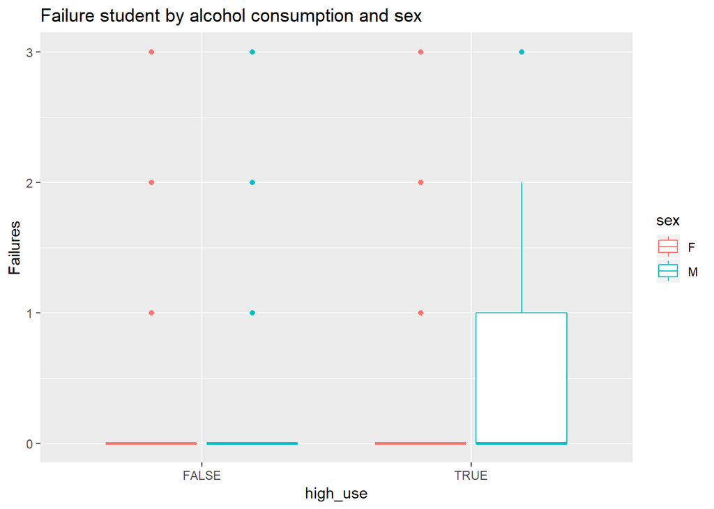

```r
# Plot high_use of alchol (true or false) based on student being fail in previous years in the school and if the results differ if student is boy or girl
Failplot <- ggplot(alc, aes(x = high_use, y = failures, col = sex))

# define the plot as a boxplot and draw it
Failplot + geom_boxplot() + ylab("Failures") +ggtitle("Failure student by alcohol consumption and sex")
```

Mostly one time fail male students tends to drink more alchol.

## Logistic regression

Here, i will use glm() function. “high_use” will be our response variable and “Fedu”, “romantic”, “absences” and “failures” as predictor variables for our logistic regression.

```r
model1 <- glm(high_use ~ Fedu +romantic + absences + failures, data = alc, family = "binomial")
summary(model1)
```

```
##
## Call:
## glm(formula = high_use ~ Fedu + romantic + absences + failures,
##     family = "binomial", data = alc)
##
## Deviance Residuals:
##     Min       1Q   Median       3Q      Max
## -2.6407  -0.7909  -0.7013   1.1088   1.9363
##
## Coefficients:
##             Estimate Std. Error z value Pr(>|z|)
## (Intercept) -1.54538    0.34269  -4.510  6.5e-06 ***
## Fedu         0.08936    0.11122   0.803 0.421697
## romanticyes -0.34134    0.26015  -1.312 0.189483
## absences     0.06885    0.01794   3.837 0.000124 ***
## failures     0.46319    0.15390   3.010 0.002615 **
## ---
## Signif. codes:  0 '***' 0.001 '**' 0.01 '*' 0.05 '.' 0.1 ' ' 1
##
## (Dispersion parameter for binomial family taken to be 1)
##
##     Null deviance: 462.21  on 381  degrees of freedom
## Residual deviance: 433.42  on 377  degrees of freedom
## AIC: 443.42
##
## Number of Fisher Scoring iterations: 4
```